# Pratical Machine Learning Peer Assessment: Personnal Activity Prediction Using Machine Learning

### Background

Using devices such as Jawbone Up, Nike FuelBand, and Fitbit it is now possible to collect a large amount of data about personal activity relatively inexpensively. These type of devices are part of the quantified self movement - a group of enthusiasts who take measurements about themselves regularly to improve their health, to find patterns in their behavior, or because they are tech geeks. One thing that people regularly do is quantify how much of a particular activity they do, but they rarely quantify how well they do it. In this project, your goal will be to use data from accelerometers on the belt, forearm, arm, and dumbell of 6 participants. They were asked to perform barbell lifts correctly and incorrectly in 5 different ways. More information is available from the website here: http://groupware.les.inf.puc-rio.br/har (see the section on the Weight Lifting Exercise Dataset).

### Data Sources

The training and test data for this project are available here:

https://d396qusza40orc.cloudfront.net/predmachlearn/pml-training.csv

https://d396qusza40orc.cloudfront.net/predmachlearn/pml-testing.csv

The original source of the data is: http://groupware.les.inf.puc-rio.br/har.

### Data processing and transformation

- Load libraries and set seed for reproducibility.
- Load the data and process it.

### How the Model is built

The outcome variable is classe, which is a factor variable with 5 levels. These 5 levels represent the 5 different fashions in which participants performed 1 set of 10 repetitions of the Unilateral Dumbbell Biceps Curl.

- exactly according to the specification (Class A)
- throwing the elbows to the front (Class B)
- lifting the dumbbell only halfway (Class C)
- lowering the dumbbell only halfway (Class D)
- throwing the hips to the front (Class E)

Class A corresponds to the specified execution of the exercise, while the other 4 classes correspond to common mistakes.The Prediction evaluation is carried out with the aim of maximizing the accuracy and minimizing the out-of-sample error. All the other availables are used for prediction. 2 prediction models are tested using decision tree and random forest algorithms and a confisuion matrix is displayed.

Decision tree and random forest algorithms are known for their ability of detecting features that are important for classification. Feature selection is inherent, so it is not so necessary at the data preparation phase. Thus, there won’t be any feature selection section in this report.

### Expected Output of Sample Error

The expected out-of-sample error corresponds to the quantity: 1 - accuracy in the cross-validation data. Accuracy is the proportion of correct classified observation over the total sample in the validation set. Expected accuracy is the expected accuracy in the out-of-sample data set (i.e. original testing data set). Thus, the expected value of the out-of-sample error will correspond to the expected number of missclassified observations/total observations in the Test data set, which is the quantity: 1 - accuracy found from the cross-validation data set.

### The code and results

```r
# Load necessary packages
library(knitr)
library(ElemStatLearn)
library(caret)
```

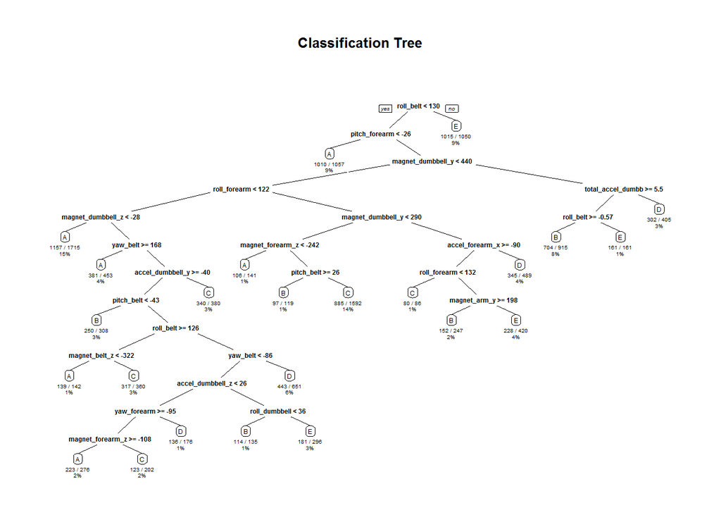

```r
library(rpart)
library(rpart.plot)
library(randomForest)
# For reproducibility, a pseudo-random number generator is set to 100.
set.seed(100)

# Assume that the data have been downloaded and stored in the working directory.
trainingData <- read.csv("pml-training.csv", header = TRUE, na.strings = c("NA", "#DIV/0!", ""))
testingData <- read.csv("pml-testing.csv", header = TRUE, na.strings = c("NA", "#DIV/0!", ""))

### Disregard the non needed id column
##trainingData <- trainingData[,-1]
##testingData <- testingData[,-1]

# Some variables are irrelevant to the prediction: user_name, raw_timestamp_part_1, raw_timestamp_part_,2 cvtd_timestamp, new_window, and  num_window (columns 1 to 7). We can delete these variables.
trainingData   <- trainingData[, -c(1:7)]
testingData <- testingData[, -c(1:7)]

# Delete columns with all missing values
trainingData <- trainingData[, colSums(is.na(trainingData)) == 0]
testingData <- testingData[, colSums(is.na(testingData)) == 0]

# Partition the training data into training and validation sets
inTrain = createDataPartition(trainingData$classe, p = 0.60, list=FALSE)
trainingSubset = trainingData[inTrain,]
validation = trainingData[-inTrain,]

### Remove non needed columns for training set
##neededCol <- c((colSums(!is.na(trainingSubset[, -ncol(trainingSubset)])) >= 0.6*nrow(trainingSubset)))
##trainingSubset   <-  trainingSubset[, neededCol]
##validation <- validation[, neededCol]

### Remove non needed columns for testing set
##neededColTestSet <- c((colSums(!is.na(testingData[, -ncol(testingData)])) >= 0.6*nrow(testingData)))
##testingData <- testingData[, neededColTestSet]

# Decision Tree model
dtModelFit <- rpart(classe ~ ., data = trainingSubset, method = "class")
dtPrediction <- predict(dtModelFit, validation, type = "class")

# Plot of the Decision Tree
rpart.plot(dtModelFit, main = "Classification Tree", extra = 102, under = TRUE, faclen = 0)
```

```r
# Test results on our validation data set
confusionMatrix(dtPrediction, validation$classe)
```

```
## Confusion Matrix and Statistics
##
##           Reference
## Prediction    A    B    C    D    E
##          A 1968  353   20  121   41
##          B   48  845   83   40   92
##          C   58  143 1170  192  163
##          D   85  111   81  837   74
##          E   73   66   14   96 1072
##
## Overall Statistics
##
##                Accuracy : 0.751
##                  95% CI : (0.7412, 0.7605)
##     No Information Rate : 0.2845
##     P-Value [Acc > NIR] : < 2.2e-16
##
##                   Kappa : 0.6839
##  Mcnemar's Test P-Value : < 2.2e-16
##
## Statistics by Class:
##
##                      Class: A Class: B Class: C Class: D Class: E
## Sensitivity            0.8817   0.5567   0.8553   0.6509   0.7434
## Specificity            0.9047   0.9584   0.9142   0.9465   0.9611
## Pos Pred Value         0.7863   0.7626   0.6779   0.7045   0.8115
## Neg Pred Value         0.9506   0.9001   0.9676   0.9326   0.9433
## Prevalence             0.2845   0.1935   0.1744   0.1639   0.1838
## Detection Rate         0.2508   0.1077   0.1491   0.1067   0.1366
## Detection Prevalence   0.3190   0.1412   0.2200   0.1514   0.1684
## Balanced Accuracy      0.8932   0.7575   0.8847   0.7987   0.8523
```

```r
# Random Forest model
rfModelFit <- randomForest(classe ~ ., data = trainingSubset)
rfPredict <- predict(rfModelFit, validation, type = "class")

# Test results on our validation data set
confusionMatrix(rfPredict, validation$classe)
```

```
## Confusion Matrix and Statistics
##
##           Reference
## Prediction    A    B    C    D    E
##          A 2230    7    1    0    0
##          B    2 1508    9    0    0
##          C    0    3 1355   17    2
##          D    0    0    3 1268    7
##          E    0    0    0    1 1433
##
## Overall Statistics
##
##                Accuracy : 0.9934
##                  95% CI : (0.9913, 0.995)
##     No Information Rate : 0.2845
##     P-Value [Acc > NIR] : < 2.2e-16
##
##                   Kappa : 0.9916
##  Mcnemar's Test P-Value : NA
##
## Statistics by Class:
##
##                      Class: A Class: B Class: C Class: D Class: E
## Sensitivity            0.9991   0.9934   0.9905   0.9860   0.9938
## Specificity            0.9986   0.9983   0.9966   0.9985   0.9998
## Pos Pred Value         0.9964   0.9928   0.9840   0.9922   0.9993
## Neg Pred Value         0.9996   0.9984   0.9980   0.9973   0.9986
## Prevalence             0.2845   0.1935   0.1744   0.1639   0.1838
## Detection Rate         0.2842   0.1922   0.1727   0.1616   0.1826
## Detection Prevalence   0.2852   0.1936   0.1755   0.1629   0.1828
## Balanced Accuracy      0.9988   0.9958   0.9936   0.9922   0.9968
```

### Final model test

```r
# Prediction on initial testing data set using Random Forest
predictTestingData <- predict(rfModelFit, testingData, type="class")
predictTestingData
```

```
##  1  2  3  4  5  6  7  8  9 10 11 12 13 14 15 16 17 18 19 20
##  B  A  B  A  A  E  D  B  A  A  B  C  B  A  E  E  A  B  B  B
## Levels: A B C D E
```

```r
# Write files for submission
pml_write_files = function(x){
  n = length(x)
  for(i in 1:n){
    filename = paste0("problem_id_", i, ".txt")
    write.table(x[i], file=filename, quote = FALSE, row.names = FALSE, col.names=FALSE)
  }
}

pml_write_files(predictTestingData)
```